# R Notebook

Call Libraries

```r
library(tidyverse)
library(janitor)
library(here)
library(lubridate)
```

**Labour_Productivity-OECD_Countries**

Read data

```r
gdp_phw <- read_csv(here("raw_data/OECD_GDP_per_Hour_Worked_JHios.csv")) %>%
  clean_names()
glimpse(gdp_phw)
```

```
Rows: 3,814
Columns: 8
$ location   <chr> "AUS", "AUS", "AUS", "AUS", "AUS", "AUS", "AUS", "AUS", "AUS", "AUS", "AUS", "AUS", "AUS", "AUS", "AUS", "AUS", "AUS", "AUS", "AUS", "AUS", "AUS", "A~
$ indicator  <chr> "GDPHRWKD", "GDPHRWKD", "GDPHRWKD", "GDPHRWKD", "GDPHRWKD", "GDPHRWKD", "GDPHRWKD", "GDPHRWKD", "GDPHRWKD", "GDPHRWKD", "GDPHRWKD", "GDPHRWKD", "GDPH~
$ subject    <chr> "TOT", "TOT", "TOT", "TOT", "TOT", "TOT", "TOT", "TOT", "TOT", "TOT", "TOT", "TOT", "TOT", "TOT", "TOT", "TOT", "TOT", "TOT", "TOT", "TOT", "TOT", "T~
$ measure    <chr> "USD", "USD", "USD", "USD", "USD", "USD", "USD", "USD", "USD", "USD", "USD", "USD", "USD", "USD", "USD", "USD", "USD", "USD", "USD", "USD", "USD", "U~
$ frequency  <chr> "A", "A", "A", "A", "A", "A", "A", "A", "A", "A", "A", "A", "A", "A", "A", "A", "A", "A", "A", "A", "A", "A", "A", "A", "A", "A", "A", "A", "A", "A",~
$ time       <dbl> 1970, 1971, 1972, 1973, 1974, 1975, 1976, 1977, 1978, 1979, 1980, 1981, 1982, 1983, 1984, 1985, 1986, 1987, 1988, 1989, 1990, 1991, 1992, 1993, 1994,~
$ value      <dbl> 26.84966, 27.51984, 28.12699, 28.70706, 28.24612, 29.29258, 29.78026, 29.74578, 31.00299, 31.16227, 31.51076, 32.41978, 32.80942, 33.70869, 34.44126,~
$ flag_codes <chr> NA, NA, NA, NA, NA, NA, NA, NA, NA, NA, NA, NA, NA, NA, NA, NA, NA, NA, NA, NA, NA, NA, NA, NA, NA, NA, NA, NA, NA, NA, NA, NA, NA, NA, NA, NA, NA, N~
```

Change time in datetime format

```r
gdp_phw <- gdp_phw %>%
  mutate(time = make_datetime(time))
```

Check for NA values

```r
gdp_phw %>%
  summarise(across(.cols = everything(),
                   .fns = ~sum(is.na(.x))))
```

| location | indicator | subject | measure | frequency | time | value | flag_codes |
| --- | --- | --- | --- | --- | --- | --- | --- |
| 0 | 0 | 0 | 0 | 0 | 0 | 0 | 3760 |

```r
gdp_phw %>%
  distinct(location)
```

| location |
| --- |
| AUS |
| AUT |
| BEL |
| CAN |
| CZE |
| DNK |
| FIN |
| FRA |
| DEU |
| GRC |

[output cut: 38 more lines]

```r
  # distinct(INDICATOR) # GFCFASSET
  # distinct(subject) # OTHMACHINEQT, CULTASSET, OTHBUILDING, FIXASSET, TRANSPEQT, DWELLING
  # distinct(MEASURE) # PC_GFCF
  # distinct(FREQUENCY) #A
  # distinct(`Flag Codes`) # NA, E, B
```

View data

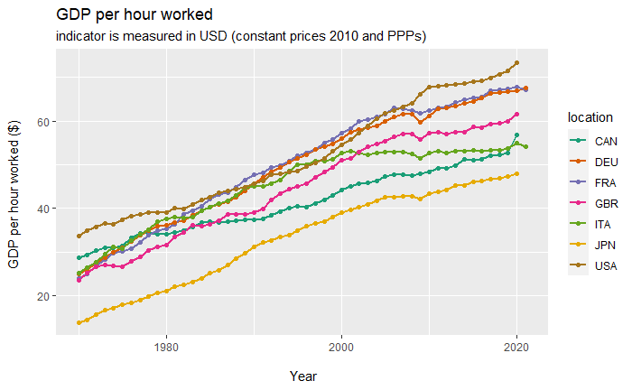

```r
gdp_phw %>%
  select(-c(indicator, subject, frequency, flag_codes)) %>%
  filter(
    location %in% c("CAN", "FRA", "DEU", "ITA", "JPN", "USA", "GBR"),
    measure == "USD") %>%
  ggplot() +
  aes(x = time, y = value, colour = location) +
  geom_line(size = 0.75) +
  geom_point(size = 1.5) +
  scale_colour_brewer(palette = "Dark2") +
  ggtitle(
    "GDP per hour worked",
    subtitle =  "indicator is measured in USD (constant prices 2010 and PPPs)"
  ) +
  labs(
    x = "\n Year",
    y = "GDP per hour worked ($) \n"
  )
```

```r
NA
```

G-7 GDP per hour worked data

```r
gdp_phw_g7 <- gdp_phw %>%
  filter(
    location %in% c("CAN", "FRA", "DEU", "ITA", "JPN", "USA", "GBR"),
    measure == "USD"
  ) %>%
  select(-c(indicator, frequency, measure, subject, flag_codes)) %>%
  rename(gdp_phw_usd = value)
```

OECD Investment by Asset

Read data

```r
inv_asset <- read_csv(here("raw_data/OECD_Investment_by_Asset_JHios.csv")) %>%
  clean_names()
glimpse(inv_asset)
```

```
Rows: 8,113
Columns: 8
$ location   <chr> "NZL", "NZL", "NZL", "NZL", "NZL", "NZL", "NZL", "NZL", "NZL", "NZL", "NZL", "NZL", "NZL", "NZL", "NZL", "NZL", "NZL", "NZL", "NZL", "NZL", "NZL", "N~
$ indicator  <chr> "GFCFASSET", "GFCFASSET", "GFCFASSET", "GFCFASSET", "GFCFASSET", "GFCFASSET", "GFCFASSET", "GFCFASSET", "GFCFASSET", "GFCFASSET", "GFCFASSET", "GFCFA~
$ subject    <chr> "OTHMACHINEQT", "OTHMACHINEQT", "OTHMACHINEQT", "OTHMACHINEQT", "OTHMACHINEQT", "OTHMACHINEQT", "OTHMACHINEQT", "OTHMACHINEQT", "OTHMACHINEQT", "OTHM~
$ measure    <chr> "PC_GFCF", "PC_GFCF", "PC_GFCF", "PC_GFCF", "PC_GFCF", "PC_GFCF", "PC_GFCF", "PC_GFCF", "PC_GFCF", "PC_GFCF", "PC_GFCF", "PC_GFCF", "PC_GFCF", "PC_GF~
$ frequency  <chr> "A", "A", "A", "A", "A", "A", "A", "A", "A", "A", "A", "A", "A", "A", "A", "A", "A", "A", "A", "A", "A", "A", "A", "A", "A", "A", "A", "A", "A", "A",~
$ time       <dbl> 1971, 1972, 1973, 1974, 1975, 1976, 1977, 1978, 1979, 1980, 1981, 1982, 1983, 1984, 1985, 1986, 1987, 1988, 1989, 1990, 1991, 1992, 1993, 1994, 1995,~
$ value      <dbl> 2.3447402, 2.3421589, 2.2280472, 2.6297086, 2.7333527, 3.1940378, 4.0083835, 4.3093129, 5.0158156, 5.4235339, 6.1697723, 7.7076256, 10.0136026, 11.29~
$ flag_codes <chr> NA, NA, NA, NA, NA, NA, NA, NA, NA, NA, NA, NA, NA, NA, NA, NA, NA, NA, NA, NA, NA, NA, NA, NA, NA, NA, NA, NA, NA, NA, NA, NA, NA, NA, NA, NA, NA, N~
```

Change time in datetime format

```r
inv_asset <- inv_asset %>%
  mutate(time = make_datetime(time))
```

Check for NA’s

```r
inv_asset %>%
  summarise(across(.cols = everything(),
                   .fns = ~sum(is.na(.x))))
```

| location | indicator | subject | measure | frequency | time | value | flag_codes |
| --- | --- | --- | --- | --- | --- | --- | --- |
| 0 | 0 | 0 | 0 | 0 | 0 | 0 | 7307 |

```r
inv_asset %>%
  distinct(location)
```

| location |
| --- |
| NZL |
| MEX |
| ZAF |
| FIN |
| CHE |
| GBR |
| NLD |
| FRA |
| GRC |
| SWE |

[output cut: 32 more lines]

```r
  # distinct(INDICATOR) # GFCFASSET
  # distinct(subject) # OTHMACHINEQT, CULTASSET, OTHBUILDING, FIXASSET, TRANSPEQT, DWELLING
  # distinct(MEASURE) # PC_GFCF
  # distinct(FREQUENCY) #A
  # distinct(`Flag Codes`) # NA, E, B
```

OTHMACHINEQT: Information and Communication Technology (ICT) equipment (computer software and databases, telecommunications equipment and computer hardware)

CULTASSET: cultivated biological resources (managed forests, livestock raised for milk production, etc.)

OTHBUILDING: other buildings and structures (roads, bridges, airfields, dams, etc.)

FIXASSET: intellectual property products (such as R&D, mineral exploration, software and databases, and literary and artistic originals, etc.)

TRANSPEQT: transport equipment (ships, trains, aircraft, etc.)

DWELLING: dwellings (excluding land)

G-7 Cross country investment by Asset (% GFCF)

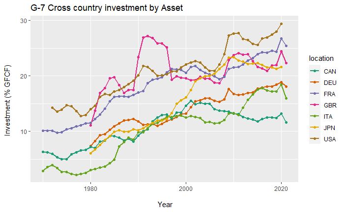

```r
inv_asset %>%
  select(-c(indicator, frequency, flag_codes)) %>%
  filter(
    location %in% c("CAN", "FRA", "DEU", "ITA", "JPN", "USA", "GBR"),
    # subject== "OTHMACHINEQT",
    # subject == "CULTASSET",
    # subject == "OTHBUILDING",
    subject == "FIXASSET",
    # subject == "TRANSPEQT",
    # subject == "DWELLING"
  ) %>%
  ggplot() +
  aes(x = time, y = value, colour = location) +
  geom_line(size = 0.75) +
  geom_point(size = 1.5) +
  scale_colour_brewer(palette = "Dark2") +
  ggtitle("G-7 Cross country investment by Asset") +
  labs(
    x = "\n Year",
    y = "Investment (% GFCF) \n"
  )
```

G-7 investment by Asset (% GFCF)

```r
inv_asset_g7 <- inv_asset %>%
  filter(
    location %in% c("CAN", "FRA", "DEU", "ITA", "JPN", "USA", "GBR")
    ) %>%
  select(-c(indicator, frequency, measure, flag_codes)) %>%
  pivot_wider(names_from = subject, values_from = value) %>%
  rename(
    ict_pc_gfcf = OTHMACHINEQT,
    cultasset_pc_gfcf = CULTASSET,
    infrastuct_pc_gfcf = OTHBUILDING,
    intelprop_pc_gfcf = FIXASSET,
    transpeqt_pc_gfcf = TRANSPEQT,
    dwelling_pc_gfcf = DWELLING
  ) %>%
  arrange(location, time)
```

OECD Investment GFCF

Read data

```r
gfcf <- read_csv(here("raw_data/OECD_Investment_GFCF_JHios.csv")) %>%
  clean_names()
glimpse(gfcf)
```

```
Rows: 23,956
Columns: 8
$ location   <chr> "AUS", "AUS", "AUS", "AUS", "AUS", "AUS", "AUS", "AUS", "AUS", "AUS", "AUS", "AUS", "AUS", "AUS", "AUS", "AUS", "AUS", "AUS", "AUS", "AUS", "AUS", "A~
$ indicator  <chr> "GFCF", "GFCF", "GFCF", "GFCF", "GFCF", "GFCF", "GFCF", "GFCF", "GFCF", "GFCF", "GFCF", "GFCF", "GFCF", "GFCF", "GFCF", "GFCF", "GFCF", "GFCF", "GFCF~
$ subject    <chr> "TOT", "TOT", "TOT", "TOT", "TOT", "TOT", "TOT", "TOT", "TOT", "TOT", "TOT", "TOT", "TOT", "TOT", "TOT", "TOT", "TOT", "TOT", "TOT", "TOT", "TOT", "T~
$ measure    <chr> "AGRWTH", "AGRWTH", "AGRWTH", "AGRWTH", "AGRWTH", "AGRWTH", "AGRWTH", "AGRWTH", "AGRWTH", "AGRWTH", "AGRWTH", "AGRWTH", "AGRWTH", "AGRWTH", "AGRWTH",~
$ frequency  <chr> "A", "A", "A", "A", "A", "A", "A", "A", "A", "A", "A", "A", "A", "A", "A", "A", "A", "A", "A", "A", "A", "A", "A", "A", "A", "A", "A", "A", "A", "A",~
$ time       <chr> "1960", "1961", "1962", "1963", "1964", "1965", "1966", "1967", "1968", "1969", "1970", "1971", "1972", "1973", "1974", "1975", "1976", "1977", "1978~
$ value      <dbl> 5.671711, 1.778081, 6.252030, 9.366150, 7.483513, 8.132420, 5.097216, 7.374136, 6.391864, 3.280286, 3.221345, 2.806477, 3.058763, 4.268170, -6.410547~
$ flag_codes <chr> NA, NA, NA, NA, NA, NA, NA, NA, NA, NA, NA, NA, NA, NA, NA, NA, NA, NA, NA, NA, NA, NA, NA, NA, NA, NA, NA, NA, NA, NA, NA, NA, NA, NA, NA, NA, NA, N~
```

Change time in datetime format

```r
gfcf <- gfcf %>%
  mutate(time = make_datetime(time))
```

Check for NA’s

```r
gfcf %>%
  summarise(across(.cols = everything(),
                   .fns = ~sum(is.na(.x))))
```

| location | indicator | subject | measure | frequency | time | value | flag_codes |
| --- | --- | --- | --- | --- | --- | --- | --- |
| 0 | 0 | 0 | 0 | 0 | 18811 | 0 | 16402 |

```r
gfcf %>%
  distinct(location)
```

| location |
| --- |
| AUS |
| AUT |
| BEL |
| CAN |
| CZE |
| DNK |
| FIN |
| FRA |
| DEU |
| GRC |

[output cut: 58 more lines]

```r
  # distinct(INDICATOR) # GFCF
  # distinct(SUBJECT) # TOT
  # distinct(measure) # AGRWTH, MLN_USD, QGRWTH
  # distinct(FREQUENCY) #A, Q
  # distinct(`Flag Codes`) # NA, E, P, B, D
```

AGRWTH: Annual growth (%) MLN_USD: Million US Dollars QGRWTH: Quarterly growth rate (%)

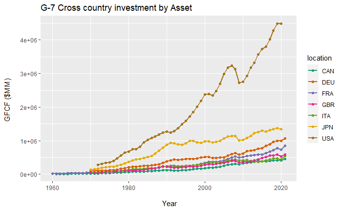

```r
gfcf %>%
  select(-c(indicator, frequency, subject, flag_codes)) %>%
  filter(
    location %in% c("CAN", "FRA", "DEU", "ITA", "JPN", "USA", "GBR"),
    measure == "MLN_USD"
    ) %>%
  ggplot() +
  aes(x = time, y = value, color = location) +
  geom_line(size = 0.75) +
  geom_point(size = 1.5) +
  scale_colour_brewer(palette = "Dark2") +
  ggtitle("G-7 Cross country investment by Asset") +
  labs(
    x = "\n Year",
    y = "GFCF ($MM) \n"
  )
```

GFCF data (mln USD)

```r
gfcf_g7 <- gfcf %>%
  filter(
    location %in% c("CAN", "FRA", "DEU", "ITA", "JPN", "USA", "GBR"),
    measure == "MLN_USD"
  ) %>%
  select(location, time, value) %>%
  rename(gfcf_mln_usd = value)
```

OECD Education Spending Expenditure

Read data

```r
edu_exp <- read_csv(here("raw_data/OECD_Public_Spending_on_Education_JHios.csv")) %>%
  clean_names()
glimpse(edu_exp)
```

```
Rows: 1,620
Columns: 8
$ location   <chr> "AUS", "AUS", "AUS", "AUS", "AUS", "AUS", "AUS", "AUS", "AUS", "AUS", "AUS", "AUS", "AUS", "AUT", "AUT", "AUT", "AUT", "AUT", "AUT", "AUT", "BEL", "B~
$ indicator  <chr> "EDUPUBEXP", "EDUPUBEXP", "EDUPUBEXP", "EDUPUBEXP", "EDUPUBEXP", "EDUPUBEXP", "EDUPUBEXP", "EDUPUBEXP", "EDUPUBEXP", "EDUPUBEXP", "EDUPUBEXP", "EDUPU~
$ subject    <chr> "TRY", "TRY", "TRY", "TRY", "TRY", "TRY", "TRY", "TRY", "TRY", "TRY", "TRY", "TRY", "TRY", "TRY", "TRY", "TRY", "TRY", "TRY", "TRY", "TRY", "TRY", "T~
$ measure    <chr> "PC_GDP", "PC_GDP", "PC_GDP", "PC_GDP", "PC_GDP", "PC_GDP", "PC_GDP", "PC_GDP", "PC_GDP", "PC_GDP", "PC_GDP", "PC_GDP", "PC_GDP", "PC_GDP", "PC_GDP",~
$ frequency  <chr> "A", "A", "A", "A", "A", "A", "A", "A", "A", "A", "A", "A", "A", "A", "A", "A", "A", "A", "A", "A", "A", "A", "A", "A", "A", "A", "A", "A", "A", "A",~
$ time       <dbl> 2000, 2005, 2008, 2009, 2010, 2011, 2012, 2013, 2014, 2015, 2016, 2017, 2018, 2012, 2013, 2014, 2015, 2016, 2017, 2018, 2005, 2008, 2009, 2010, 2011,~
$ value      <dbl> 0.7460824, 0.6911921, 0.6902357, 0.7358844, 0.7797844, 0.7440488, 0.7194145, 0.7188712, 0.7170264, 0.7682429, 0.7551060, 0.7273703, 0.6545624, 1.6615~
$ flag_codes <lgl> NA, NA, NA, NA, NA, NA, NA, NA, NA, NA, NA, NA, NA, NA, NA, NA, NA, NA, NA, NA, NA, NA, NA, NA, NA, NA, NA, NA, NA, NA, NA, NA, NA, NA, NA, NA, NA, N~
```

Change time in datetime format

```r
edu_exp <- edu_exp %>%
  mutate(time = make_datetime(time))
```

Check for NA’s

```r
edu_exp %>%
  summarise(across(.cols = everything(),
                   .fns = ~sum(is.na(.x))))
```

| location | indicator | subject | measure | frequency | time | value | flag_codes |
| --- | --- | --- | --- | --- | --- | --- | --- |
| 0 | 0 | 0 | 0 | 0 | 0 | 0 | 1620 |

```r
edu_exp %>%
  distinct(location)
```

| location |
| --- |
| AUS |
| AUT |
| BEL |
| CAN |
| CZE |
| DNK |
| FIN |
| FRA |
| DEU |
| HUN |

[output cut: 36 more lines]

```r
  # distinct(INDICATOR) #
  # distinct(SUBJECT) #
  # distinct(measure) #
  # distinct(FREQUENCY) #
  # distinct(`Flag Codes`) #
```

UK education expenditure (% GDP) TRY : TeRtiarY PRY_NTRY: PRimarY to post-secondary Non-TeRtiarY PRY_TRY: PRimarY to TeRtiarY

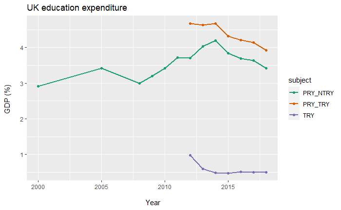

```r
edu_exp %>%
  select(-c(indicator, frequency, measure, flag_codes)) %>%
  filter(location %in% c("GBR")) %>%
  ggplot() +
  aes(x = time, y = value, colour = subject) +
  geom_line(size = 0.75) +
  geom_point(size = 1.5) +
  scale_colour_brewer(palette = "Dark2") +
  # scale_colour_manual(values = cbb_palette) +
  ggtitle("UK education expenditure") +
  labs(
    x = "\n Year",
    y = "GDP (%) \n"
  )
```

G-7 expenditure on education (% GDP)

```r
edu_exp_g7 <- edu_exp %>%
  filter(
    location %in% c("CAN", "FRA", "DEU", "ITA", "JPN", "USA", "GBR")
    ) %>%
  select(-c(indicator, frequency, measure, flag_codes)) %>%
  pivot_wider(names_from = subject, values_from = value) %>%
  rename(
    try_pc_gdp = TRY,
    pry_ntry_pc_gdp = PRY_NTRY,
    pry_try_pc_gdp = PRY_TRY
  ) %>%
  arrange(location, time)
```

**GDP-derived expenditure in USD**

OECD_Gross_Domestic_Product_GDP

Read data

```r
gdp <- read_csv(here("raw_data/OECD_Gross_Domestic_Product_GDP_JHios.csv")) %>%
  clean_names()
glimpse(gdp)
```

```
Rows: 5,137
Columns: 8
$ location   <chr> "AUS", "AUS", "AUS", "AUS", "AUS", "AUS", "AUS", "AUS", "AUS", "AUS", "AUS", "AUS", "AUS", "AUS", "AUS", "AUS", "AUS", "AUS", "AUS", "AUS", "AUS", "A~
$ indicator  <chr> "GDP", "GDP", "GDP", "GDP", "GDP", "GDP", "GDP", "GDP", "GDP", "GDP", "GDP", "GDP", "GDP", "GDP", "GDP", "GDP", "GDP", "GDP", "GDP", "GDP", "GDP", "G~
$ subject    <chr> "TOT", "TOT", "TOT", "TOT", "TOT", "TOT", "TOT", "TOT", "TOT", "TOT", "TOT", "TOT", "TOT", "TOT", "TOT", "TOT", "TOT", "TOT", "TOT", "TOT", "TOT", "T~
$ measure    <chr> "MLN_USD", "MLN_USD", "MLN_USD", "MLN_USD", "MLN_USD", "MLN_USD", "MLN_USD", "MLN_USD", "MLN_USD", "MLN_USD", "MLN_USD", "MLN_USD", "MLN_USD", "MLN_U~
$ frequency  <chr> "A", "A", "A", "A", "A", "A", "A", "A", "A", "A", "A", "A", "A", "A", "A", "A", "A", "A", "A", "A", "A", "A", "A", "A", "A", "A", "A", "A", "A", "A",~
$ time       <dbl> 1960, 1961, 1962, 1963, 1964, 1965, 1966, 1967, 1968, 1969, 1970, 1971, 1972, 1973, 1974, 1975, 1976, 1977, 1978, 1979, 1980, 1981, 1982, 1983, 1984,~
$ value      <dbl> 25073.26, 25364.88, 27955.36, 30432.98, 32745.29, 34542.34, 38344.55, 41068.68, 46560.93, 52215.40, 58858.35, 64135.62, 69807.50, 78843.21, 86323.11,~
$ flag_codes <chr> NA, NA, NA, NA, NA, NA, NA, NA, NA, NA, NA, NA, NA, NA, NA, NA, NA, NA, NA, NA, NA, NA, NA, NA, NA, NA, NA, NA, NA, NA, NA, NA, NA, NA, NA, NA, NA, N~
```

Change time in datetime format

```r
gdp <- gdp %>%
  mutate(time = make_datetime(time))
```

Check for NA’s

```r
gdp %>%
  summarise(across(.cols = everything(),
                   .fns = ~sum(is.na(.x))))
```

| location | indicator | subject | measure | frequency | time | value | flag_codes |
| --- | --- | --- | --- | --- | --- | --- | --- |
| 0 | 0 | 0 | 0 | 0 | 0 | 0 | 3824 |

```r
gdp %>%
  distinct(location)
```

| location |
| --- |
| AUS |
| AUT |
| BEL |
| CAN |
| CZE |
| DNK |
| FIN |
| FRA |
| DEU |
| GRC |

[output cut: 57 more lines]

```r
  # distinct(indicator) # GDP
  # distinct(SUBJECT) # TOT
  # distinct(MEASURE) # MLN_USD, USD_CAP
  # distinct(FREQUENCY) #A
  # distinct(`Flag Codes`) # NA, E, P, B, D
```

View data

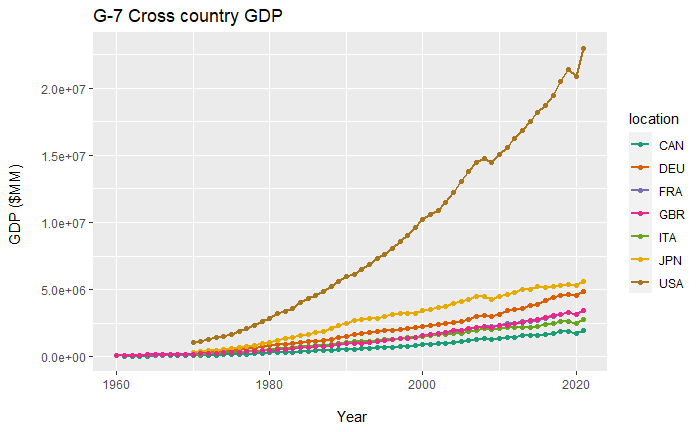

```r
gdp %>%
  select(-c(indicator, subject, frequency, flag_codes)) %>%
  filter(
    location %in% c("CAN", "FRA", "DEU", "ITA", "JPN", "USA", "GBR"),
    measure == "MLN_USD"
    ) %>%
  ggplot() +
  aes(x = time, y = value, group = location, color = location) +
  geom_line(size = 0.75) +
  geom_point(size = 1.5) +
  scale_colour_brewer(palette = "Dark2") +
  ggtitle("G-7 Cross country GDP") +
  labs(
    x = "\n Year",
    y = "GDP ($MM) \n"
  )
```

GDP data (mln USD)

```r
gdp_g7 <- gdp %>%
  filter(
    location %in% c("CAN", "FRA", "DEU", "ITA", "JPN", "USA", "GBR"),
    measure == "MLN_USD"
  ) %>%
  select(location, time, value) %>%
  rename(gdp_mln_usd = value)
```

**OECD Hrs worked**

OECD_Hours_Worked

Read data

```r
hrswrkd <- read_csv(here("raw_data/OECD_Hours_Worked_JHios.csv")) %>%
  clean_names()
glimpse(hrswrkd)
```

```
Rows: 1,752
Columns: 8
$ location   <chr> "AUS", "AUS", "AUS", "AUS", "AUS", "AUS", "AUS", "AUS", "AUS", "AUS", "AUS", "AUS", "AUS", "AUS", "AUS", "AUS", "AUS", "AUS", "AUS", "AUS", "AUS", "A~
$ indicator  <chr> "HRWKD", "HRWKD", "HRWKD", "HRWKD", "HRWKD", "HRWKD", "HRWKD", "HRWKD", "HRWKD", "HRWKD", "HRWKD", "HRWKD", "HRWKD", "HRWKD", "HRWKD", "HRWKD", "HRWK~
$ subject    <chr> "TOT", "TOT", "TOT", "TOT", "TOT", "TOT", "TOT", "TOT", "TOT", "TOT", "TOT", "TOT", "TOT", "TOT", "TOT", "TOT", "TOT", "TOT", "TOT", "TOT", "TOT", "T~
$ measure    <chr> "HR_WKD", "HR_WKD", "HR_WKD", "HR_WKD", "HR_WKD", "HR_WKD", "HR_WKD", "HR_WKD", "HR_WKD", "HR_WKD", "HR_WKD", "HR_WKD", "HR_WKD", "HR_WKD", "HR_WKD",~
$ frequency  <chr> "A", "A", "A", "A", "A", "A", "A", "A", "A", "A", "A", "A", "A", "A", "A", "A", "A", "A", "A", "A", "A", "A", "A", "A", "A", "A", "A", "A", "A", "A",~
$ time       <dbl> 1985, 1986, 1987, 1988, 1989, 1990, 1991, 1992, 1993, 1994, 1995, 1996, 1997, 1998, 1999, 2000, 2001, 2002, 2003, 2004, 2005, 2006, 2007, 2008, 2009,~
$ value      <dbl> 1876, 1877, 1889, 1885, 1875, 1853, 1854, 1846, 1856, 1874, 1870, 1862, 1861, 1850, 1856, 1852, 1829, 1818, 1807, 1811, 1808, 1802, 1803, 1799, 1767,~
$ flag_codes <lgl> NA, NA, NA, NA, NA, NA, NA, NA, NA, NA, NA, NA, NA, NA, NA, NA, NA, NA, NA, NA, NA, NA, NA, NA, NA, NA, NA, NA, NA, NA, NA, NA, NA, NA, NA, NA, NA, N~
```

Change time in datetime format

```r
hrswrkd <- hrswrkd %>%
  mutate(time = make_datetime(time))
```

Check for NA’s

```r
hrswrkd %>%
  summarise(across(.cols = everything(),
                   .fns = ~sum(is.na(.x))))
```

| location | indicator | subject | measure | frequency | time | value | flag_codes |
| --- | --- | --- | --- | --- | --- | --- | --- |
| 0 | 0 | 0 | 0 | 0 | 0 | 0 | 1752 |

```r
hrswrkd %>%
  distinct(location)
```

| location |
| --- |
| AUS |
| AUT |
| BEL |
| CAN |
| CZE |
| DNK |
| FIN |
| FRA |
| DEU |
| GRC |

[output cut: 36 more lines]

```r
  # distinct(indicator) #
  # distinct(SUBJECT) #
  # distinct(measure) # HR_WKD
  # distinct(FREQUENCY) #
  # distinct(`Flag Codes`) #
```

View data

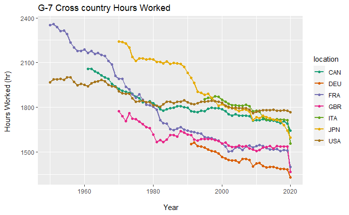

```r
hrswrkd %>%
  select(-c(indicator, subject, frequency, flag_codes)) %>%
  filter(
    location %in% c("CAN", "FRA", "DEU", "ITA", "JPN", "USA", "GBR"),
    measure == "HR_WKD"
    ) %>%
  ggplot() +
  aes(x = time, y = value, group = location, color = location) +
  geom_line(size = 0.75) +
  geom_point(size = 1.5) +
  scale_colour_brewer(palette = "Dark2") +
  ggtitle("G-7 Cross country Hours Worked") +
  labs(
    x = "\n Year",
    y = "Hours Worked (hr) \n"
  )
```

Hours Worked (hrs)

```r
hrswrkd_g7 <- hrswrkd %>%
  filter(
    location %in% c("CAN", "FRA", "DEU", "ITA", "JPN", "USA", "GBR"),
    measure == "HR_WKD"
  ) %>%
  select(location, time, value) %>%
  rename(hrs_wrkd = value)
```

**OECD data for clustering**

```r
productivity_data <- gdp_phw_g7 %>%
  left_join(edu_exp_g7, by = c("location", "time")) %>%
  left_join(inv_asset_g7, by = c("location", "time")) %>%
  left_join(gdp_g7, by = c("location", "time")) %>%
  left_join(gfcf_g7, by = c("location", "time")) %>%
  left_join(hrswrkd_g7, by = c("location", "time"))

glimpse(productivity_data)
```

```
Rows: 360
Columns: 15
$ location           <chr> "CAN", "CAN", "CAN", "CAN", "CAN", "CAN", "CAN", "CAN", "CAN", "CAN", "CAN", "CAN", "CAN", "CAN", "CAN", "CAN", "CAN", "CAN", "CAN", "CAN", "~
$ time               <dttm> 1970-01-01, 1971-01-01, 1972-01-01, 1973-01-01, 1974-01-01, 1975-01-01, 1976-01-01, 1977-01-01, 1978-01-01, 1979-01-01, 1980-01-01, 1981-01-~
$ gdp_phw_usd        <dbl> 28.62992, 29.33436, 30.35025, 31.07351, 31.07195, 31.42778, 33.28053, 34.20403, 34.45608, 34.11693, 34.01649, 34.48396, 34.95985, 35.77264, 3~
$ try_pc_gdp         <dbl> NA, NA, NA, NA, NA, NA, NA, NA, NA, NA, NA, NA, NA, NA, NA, NA, NA, NA, NA, NA, NA, NA, NA, NA, NA, NA, NA, NA, NA, NA, 1.485331, NA, NA, NA,~
$ pry_ntry_pc_gdp    <dbl> NA, NA, NA, NA, NA, NA, NA, NA, NA, NA, NA, NA, NA, NA, NA, NA, NA, NA, NA, NA, NA, NA, NA, NA, NA, NA, NA, NA, NA, NA, 3.197672, NA, NA, NA,~
$ pry_try_pc_gdp     <dbl> NA, NA, NA, NA, NA, NA, NA, NA, NA, NA, NA, NA, NA, NA, NA, NA, NA, NA, NA, NA, NA, NA, NA, NA, NA, NA, NA, NA, NA, NA, 4.683004, NA, NA, NA,~
$ ict_pc_gfcf        <dbl> NA, NA, NA, NA, NA, NA, 5.908043, 5.735586, 5.798956, 5.730270, 6.064422, 7.010482, 7.453742, 8.099351, 8.435067, 8.714675, 8.695220, 9.13341~
$ dwelling_pc_gfcf   <dbl> 23.16589, 25.25588, 27.36654, 28.79571, 28.00688, 25.61004, 29.66266, 28.94404, 28.31702, 26.22259, 23.53972, 23.38057, 20.84080, 25.01044, 2~
$ infrastuct_pc_gfcf <dbl> 41.24392, 41.10314, 38.81326, 36.86076, 37.48857, 39.57957, 35.61356, 36.35557, 35.86742, 36.41802, 38.10420, 37.93646, 40.26276, 36.70336, 3~
$ cultasset_pc_gfcf  <dbl> NA, NA, NA, NA, NA, NA, NA, NA, NA, NA, NA, NA, NA, NA, NA, NA, NA, NA, NA, NA, NA, NA, NA, NA, NA, NA, NA, NA, NA, NA, NA, NA, NA, NA, NA, N~
$ transpeqt_pc_gfcf  <dbl> NA, NA, NA, NA, NA, NA, NA, NA, NA, NA, NA, 5.117076, 4.180031, 5.036410, 6.153433, 6.258572, 6.115449, 6.439665, 6.355651, 5.822806, 5.12864~
$ intelprop_pc_gfcf  <dbl> 6.348655, 6.211180, 5.949593, 5.352411, 4.959944, 4.982173, 5.834575, 6.237614, 6.535496, 6.638818, 7.191358, 6.995291, 8.154600, 8.348857, 9~
$ gdp_mln_usd        <dbl> 99531.47, 108728.86, 119678.51, 134865.97, 151824.30, 168311.19, 188012.92, 206560.67, 229233.66, 257465.23, 286773.33, 324813.80, 333889.39,~
$ gfcf_mln_usd       <dbl> 21506.30, 24425.74, 26537.53, 30597.19, 35674.96, 40832.56, 44720.91, 48091.51, 52603.58, 60012.22, 68437.95, 81267.38, 75354.15, 74841.86, 7~
$ hrs_wrkd           <dbl> 1925, 1912, 1904, 1898, 1891, 1872, 1862, 1834, 1836, 1841, 1827, 1812, 1789, 1779, 1789, 1795, 1797, 1807, 1808, 1802, 1797, 1775, 1772, 176~
```

```r
productivity_data %>%
  mutate(time = year(time)) %>%
  filter(time == 2018)
```

| location | time | gdp_phw_usd | try_pc_gdp | pry_ntry_pc_gdp | pry_try_pc_gdp | ict_pc_gfcf | dwelling_pc_gfcf | infrastuct_pc_gfcf | cultasset_pc_gfcf | transpeqt_pc_gfcf | intelprop_pc_gfcf | gdp_mln_usd | gfcf_mln_usd | hrs_wrkd |
| --- | --- | --- | --- | --- | --- | --- | --- | --- | --- | --- | --- | --- | --- | --- |
| CAN | 2018 | 52.21283 | 1.2177830 | 3.223512 | 4.441295 | 10.723843 | 33.63551 | 35.39470 | NA | 4.644039 | 12.51522 | 1849252 | 417194.2 | 1708.0 |
| FRA | 2018 | 67.15515 | 1.1249240 | 3.366300 | 4.491224 | 16.406327 | 27.73690 | 25.13368 | 0.185574366 | 7.395804 | 24.56920 | 3125380 | 715481.8 | 1514.0 |
| DEU | 2018 | 66.43817 | 1.0352350 | 2.636021 | 3.671256 | 6.824248 | 29.66171 | 19.05603 | 0.007755469 | 9.693772 | 18.06996 | 4579333 | 964279.4 | 1386.9 |
| ITA | 2018 | 53.39327 | 0.5585754 | 2.927140 | 3.485715 | 12.578667 | 22.89190 | 21.36659 | 0.208936405 | 7.193391 | 17.17777 | 2600327 | 464057.9 | 1719.4 |
| JPN | 2018 | 46.89711 | 0.4438480 | 2.381728 | 2.825576 | NA | 15.00357 | 30.69316 | 0.178401768 | 5.655044 | 21.55554 | 5340832 | 1346996.3 | 1680.0 |
| GBR | 2018 | 59.53455 | 0.4985198 | 3.420327 | 3.918847 | 14.257990 | 22.06700 | 34.13591 | 0.369504016 | 5.402056 | 21.88432 | 3161748 | 561954.2 | 1536.0 |
| USA | 2018 | 70.65395 | 0.8992977 | 3.209809 | 4.109107 | 16.690224 | 18.54006 | 22.35882 | NA | 8.492998 | 27.45443 | 20527159 | 4281680.0 | 1782.0 |

JPN 2018 : replace NA with median of other countries for 2018 ict_pc_gfcf CAN 2018 : replace NA with median of other countries for 2018 cultasset_pc_gfcf USA 2018 : replace NA with median of other countries for 2018 cultasset_pc_gfcf

[output not shown]

[output cut: 350 more lines]

[output not shown]

[output cut: 350 more lines]

Prepare data for dendrogram

```r
productivity_data <- productivity_data %>%
  mutate(time = year(time)) %>%
  filter(time == 2018) %>%
  select(-time) %>%
  column_to_rownames("location")
```

Standardise data

```r
productivity_data_scale <- productivity_data %>%
  mutate(across(where(is.numeric), scale))

productivity_data_scale
```

|  | gdp_phw_usd | try_phw_usd | pry_ntry_phw_usd | pry_try_phw_usd | ict_phw_usd | dwelling_phw_usd | infrastuct_phw_usd | cultasset_phw_usd | transpeqt_phw_usd | intelprop_phw_usd |
| --- | --- | --- | --- | --- | --- | --- | --- | --- | --- | --- |
| CAN | -0.810982248 | 0.5918601 | -0.3102124 | 0.008769374 | -0.5873576 | -0.5883908 | -0.6026338 | -0.516828206 | -0.6845454 | -0.66419484 |
| FRA | 0.858972054 | 1.1228451 | 1.0872749 | 1.204638777 | -0.2009790 | -0.2237979 | -0.4074117 | -0.320302176 | -0.3341832 | -0.27323425 |
| DEU | 0.778842457 | 0.8225006 | -0.1451018 | 0.214935108 | -0.4274022 | 0.3362973 | -0.3245657 | -0.791164257 | 0.1473791 | -0.22968669 |
| ITA | -0.679056010 | -0.9068936 | -0.6010329 | -0.776492801 | -0.5289907 | -0.7402300 | -0.7765102 | -0.499406981 | -0.5647599 | -0.59201455 |
| JPN | -1.405067295 | -1.3068447 | -1.6800387 | -1.695954948 | -0.0969959 | -0.3041543 | 0.3615859 | -0.003701154 | -0.1799782 | -0.01399041 |
| GBR | 0.007293093 | -0.9133316 | 0.5443831 | 0.033027671 | -0.3919074 | -0.5990063 | -0.3704944 | -0.048635706 | -0.5595788 | -0.43797289 |
| USA | 1.249997949 | 0.5898640 | 1.1047278 | 1.011076819 | 2.2336327 | 2.1192820 | 2.1200299 | 2.180038480 | 2.1756664 | 2.21109364 |

Check data if mean==0 and std==1

```r
productivity_data_scale %>%
  pivot_longer(cols = everything(),
               names_to = "type",
               values_to = "value") %>% #convert data to long format
  group_by(type) %>%
  summarise(mean = round(mean(value)),
            sd = sd(value))
```

| type | mean | sd |
| --- | --- | --- |
| cultasset_phw_usd | 0 | 1 |
| dwelling_phw_usd | 0 | 1 |
| gdp_phw_usd | 0 | 1 |
| ict_phw_usd | 0 | 1 |
| infrastuct_phw_usd | 0 | 1 |
| intelprop_phw_usd | 0 | 1 |
| pry_ntry_phw_usd | 0 | 1 |
| pry_try_phw_usd | 0 | 1 |
| transpeqt_phw_usd | 0 | 1 |
| try_phw_usd | 0 | 1 |

Check if variables are correlated

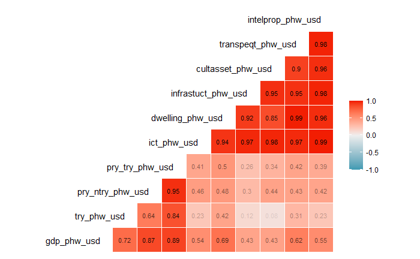

```r
GGally::ggcorr(productivity_data_scale,
    label = TRUE,
    label_size = 3,
    label_round = 2,
    label_alpha = TRUE,
    hjust = 1,
    layout.exp = 0.5
  )
```

Call libraries

```r
library(cluster)
library(factoextra)
library(dendextend)
library(corrplot)
```

Take productivity GDP pwh

```r
diss_matrix_gdp_phw <- productivity_data_scale %>%
              select(gdp_phw_usd) %>%
              dist(method = "euclidean")
```

Create a dissimilarity matrix showing distances

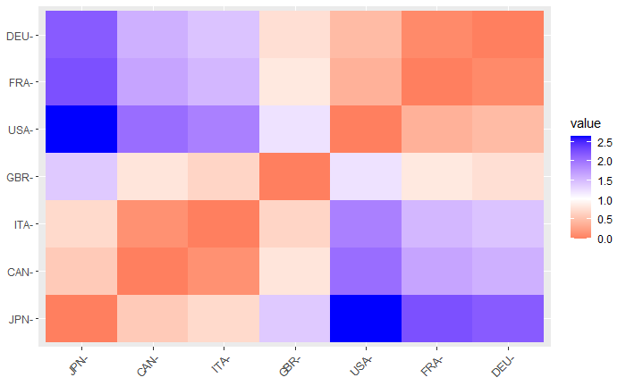

```r
fviz_dist(diss_matrix_gdp_phw)
```

Build dendrogram

```r
clusters_gdp_phw <- diss_matrix_gdp_phw %>%
                 hclust(method = "complete")
```

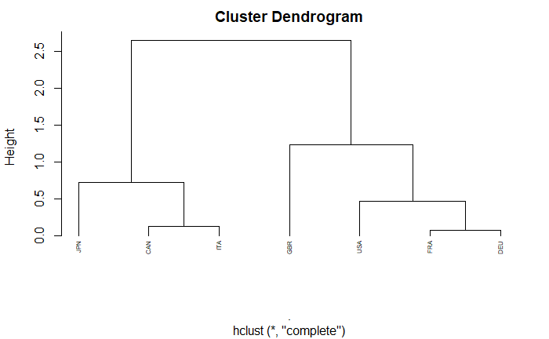

```r
clusters_gdp_phw %>%
  plot(cex = 0.5, hang = -5)
```

Take investments on TRY

```r
diss_matrix_try_phw_usd <- productivity_data_scale %>%
              select(try_phw_usd) %>%
              dist(method = "euclidean")
```

Create a dissimilarity matrix showing distances

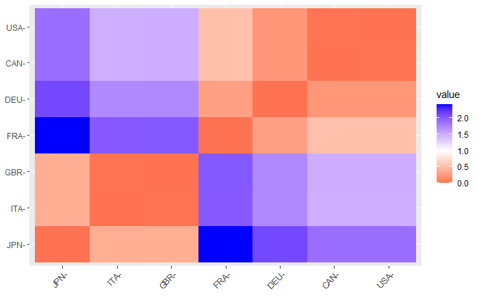

```r
fviz_dist(diss_matrix_try_phw_usd)
```

Build dendrogram

```r
clusters_try_phw_usd <- diss_matrix_try_phw_usd %>%
                 hclust(method = "complete")
```

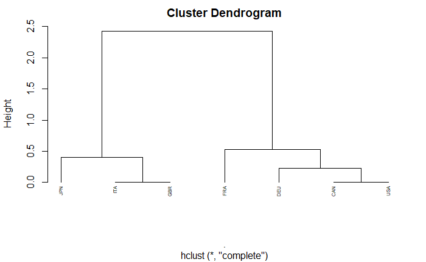

```r
clusters_try_phw_usd %>%
  plot(cex = 0.5, hang = -5)
```

Take pinestments on PRY_NTRY

```r
diss_matrix_pry_ntry_phw_usd <- productivity_data_scale %>%
              select(pry_ntry_phw_usd) %>%
              dist(method = "euclidean")
```

Create a dissimilarity matrix showing distances

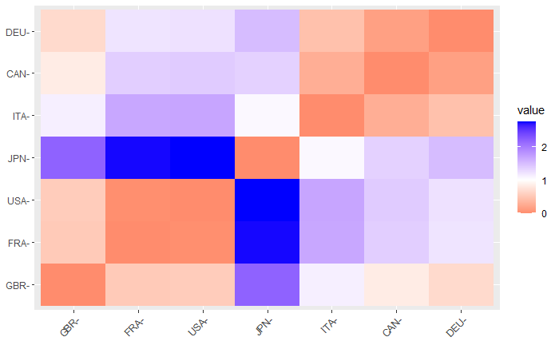

```r
fviz_dist(diss_matrix_pry_ntry_phw_usd)
```

Build dendrogram

```r
clusters_pry_ntry_phw_usd <- diss_matrix_pry_ntry_phw_usd %>%
                 hclust(method = "complete")
```

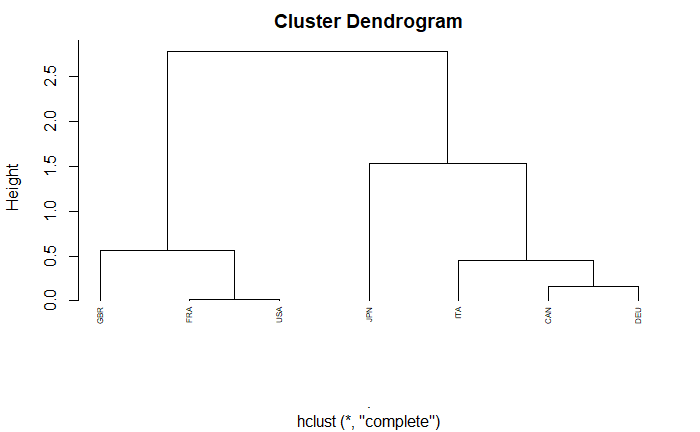

```r
clusters_pry_ntry_phw_usd %>%
  plot(cex = 0.5, hang = -5)
```

Take investments on PRY_TRY

```r
diss_matrix_pry_try_phw_usd <- productivity_data_scale %>%
              select(pry_try_phw_usd) %>%
              dist(method = "euclidean")
```

Create a dissimilarity matrix showing distances

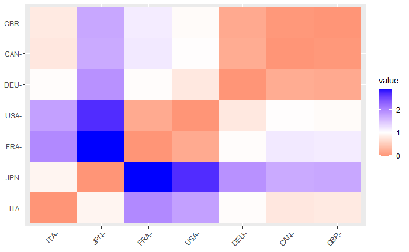

```r
fviz_dist(diss_matrix_pry_try_phw_usd)
```

Build dendrogram

```r
clusters_pry_try_phw_usd <- diss_matrix_pry_try_phw_usd %>%
                 hclust(method = "complete")
```

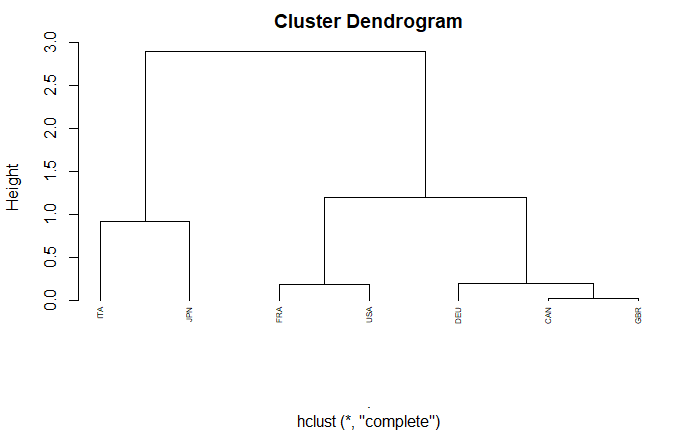

```r
clusters_pry_try_phw_usd %>%
  plot(cex = 0.5, hang = -5)
```

Take investments on ICT

```r
diss_matrix_ict_phw_usd <- productivity_data_scale %>%
              select(ict_phw_usd) %>%
              dist(method = "euclidean")
```

Create a dissimilarity matrix showing distances

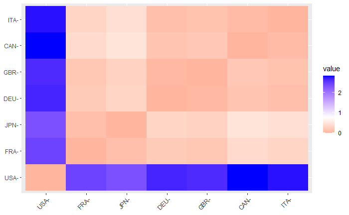

```r
fviz_dist(diss_matrix_ict_phw_usd)
```

Build dendrogram

```r
clusters_ict_phw_usd <- diss_matrix_ict_phw_usd %>%
                 hclust(method = "complete")
```

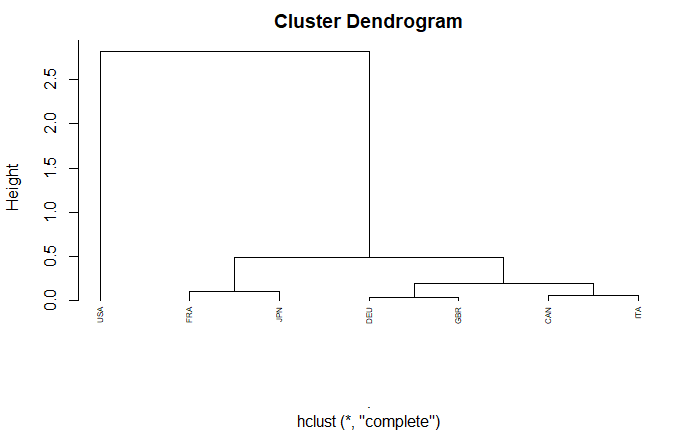

```r
clusters_ict_phw_usd %>%
  plot(cex = 0.5, hang = -5)
```

Take investments on Dwelling

```r
diss_matrix_dwelling_phw_usd <- productivity_data_scale %>%
              select(dwelling_phw_usd) %>%
              dist(method = "euclidean")
```

Create a dissimilarity matrix showing distances

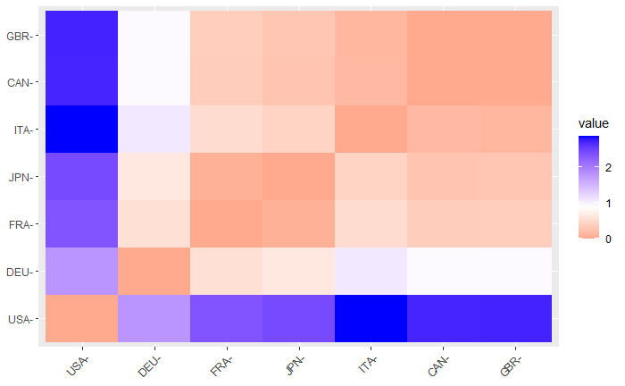

```r
fviz_dist(diss_matrix_dwelling_phw_usd)
```

Build dendrogram

```r
clusters_dwelling_phw_usd <- diss_matrix_dwelling_phw_usd %>%
                 hclust(method = "complete")
```

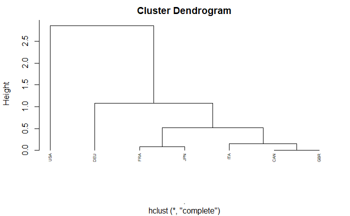

```r
clusters_dwelling_phw_usd %>%
  plot(cex = 0.5, hang = -5)
```

Take investments on Infrastructure

```r
diss_matrix_infrastuct_phw_usd <- productivity_data_scale %>%
              select(infrastuct_phw_usd) %>%
              dist(method = "euclidean")
```

Create a dissimilarity matrix showing distances

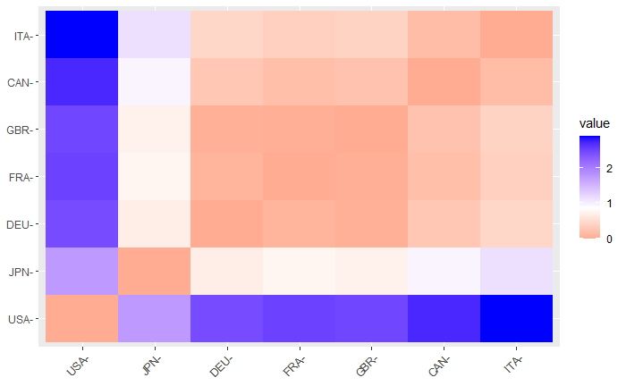

```r
fviz_dist(diss_matrix_infrastuct_phw_usd)
```

Build dendrogram

```r
clusters_infrastuct_phw_usd <- diss_matrix_infrastuct_phw_usd %>%
                 hclust(method = "complete")
```

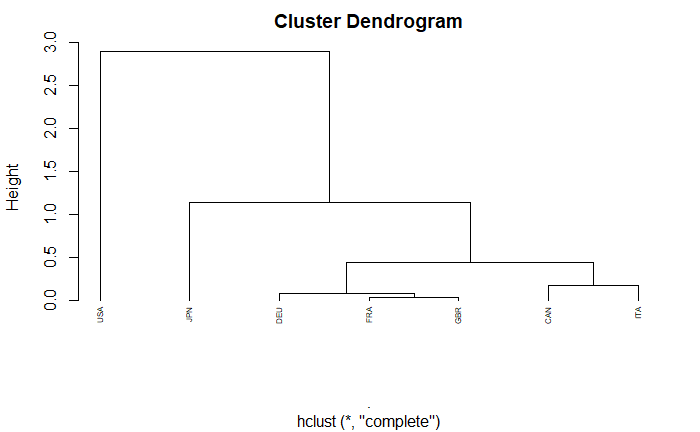

```r
clusters_infrastuct_phw_usd %>%
  plot(cex = 0.5, hang = -5)
```

Take investments on Cultasset

```r
diss_matrix_cultasset_phw_usd <- productivity_data_scale %>%
              select(cultasset_phw_usd) %>%
              dist(method = "euclidean")
```

Create a dissimilarity matrix showing distances

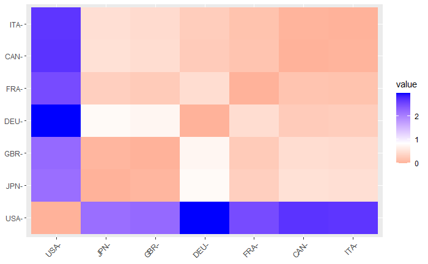

```r
fviz_dist(diss_matrix_cultasset_phw_usd)
```

Build dendrogram

```r
clusters_cultasset_phw_usd <- diss_matrix_cultasset_phw_usd %>%
                 hclust(method = "complete")
```

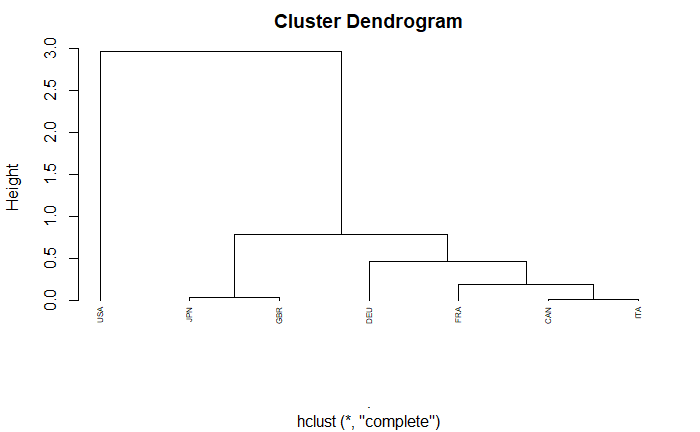

```r
clusters_cultasset_phw_usd %>%
  plot(cex = 0.5, hang = -5)
```

Take investments on Transpeqt

```r
diss_matrix_transpeqt_phw_usd <- productivity_data_scale %>%
              select(transpeqt_phw_usd) %>%
              dist(method = "euclidean")
```

Create a dissimilarity matrix showing distances

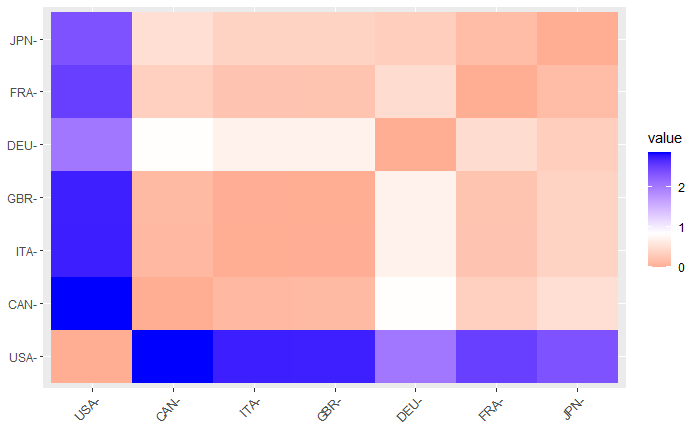

```r
fviz_dist(diss_matrix_transpeqt_phw_usd)
```

Build dendrogram

```r
clusters_transpeqt_phw_usd <- diss_matrix_transpeqt_phw_usd %>%
                 hclust(method = "complete")
```

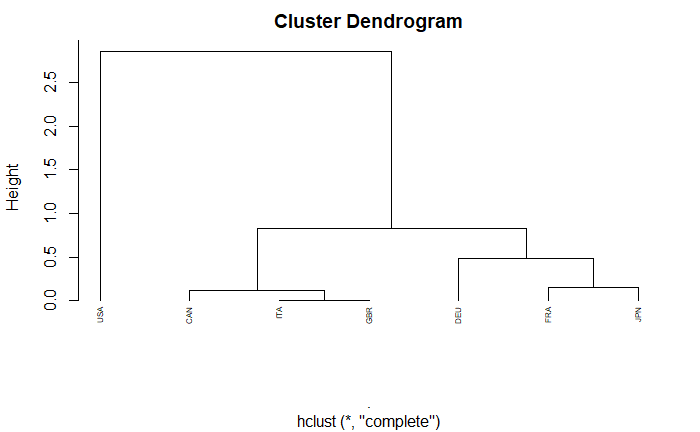

```r
clusters_transpeqt_phw_usd %>%
  plot(cex = 0.5, hang = -5)
```

Take investments on intelprop

```r
diss_matrix_intelprop_phw_usd <- productivity_data_scale %>%
              select(intelprop_phw_usd) %>%
              dist(method = "euclidean")
```

Create a dissimilarity matrix showing distances

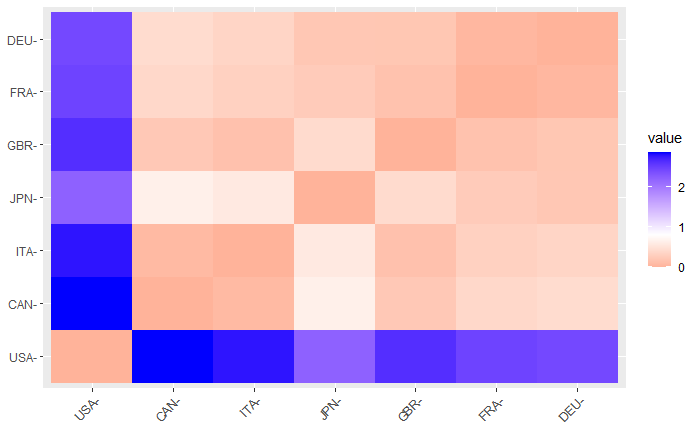

```r
fviz_dist(diss_matrix_intelprop_phw_usd)
```

Build dendrogram

```r
clusters_intelprop_phw_usd <- diss_matrix_intelprop_phw_usd %>%
                 hclust(method = "complete")
```

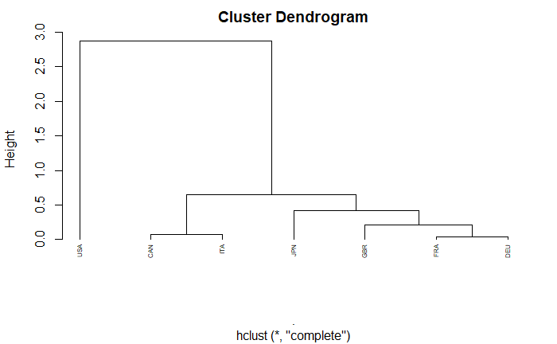

```r
clusters_intelprop_phw_usd %>%
  plot(cex = 0.5, hang = -5)
```

**Compare productivity by industry in UK and EU Countries**

Call library

```r
library(readxl)
```

Load Data

```r
prod_industry_phw <- read_excel(here("raw_data/International_Labour_Productivity-Europe.xls"), sheet = "Table 1 R-proc")
prod_industry_growth <- read_excel(here("raw_data/International_Labour_Productivity-Europe.xls"), sheet = "Table 2 R-proc")


glimpse(prod_industry_phw)
```

```
Rows: 9
Columns: 31
$ `A*10 (excl L)`  <chr> "A", "B-E", "F", "G-I", "J", "K", "M-N", "O-Q", "R-U"
$ `NACE Industry`  <chr> "Agriculture, forestry and fishing", "Industry (except construction)", "Construction", "Wholesale and retail trade, transport, accommodation an~
$ Belgium          <dbl> 25.66616, 60.19409, 38.87564, 41.93782, 59.65125, 88.10338, 24.53516, 28.17312, 19.69698
$ Bulgaria         <dbl> 2.600904, 12.304376, 9.656289, 8.787120, 29.345819, 63.410313, 14.696489, 20.903489, 18.492694
$ `Czech Republic` <dbl> 14.05971, 23.72004, 13.17658, 15.50173, 40.03371, 59.11678, 19.91482, 25.96555, 17.04386
$ Denmark          <dbl> 31.74844, 68.35846, 24.29677, 34.50571, 46.87635, 72.01052, 26.97661, 24.77941, 22.36061
$ Germany          <dbl> 19.49727, 52.43710, 20.68757, 29.74980, 60.08252, 51.46037, 31.99290, 27.90071, 22.09946
$ Estonia          <dbl> 16.88883, 17.08604, 13.67928, 14.98199, 31.06519, 57.22183, 24.90567, 15.93756, 10.01729
$ Ireland          <dbl> 9.591133, 72.697607, 25.150283, 25.012769, 100.300137, 62.397006, 36.499863, 22.530640, 17.449500
$ Greece           <dbl> 5.210345, 27.074545, 15.911999, 13.549916, 27.128820, 49.926840, 12.507425, 25.603642, 12.489497
$ Spain            <dbl> 19.88720, 44.38977, 34.85822, 23.12436, 43.96195, 55.78498, 19.17254, 24.39174, 14.69544
$ France           <dbl> 18.03665, 47.50529, 24.92221, 32.25440, 62.20943, 53.23991, 31.13475, 29.20290, 18.40162
$ Croatia          <dbl> 6.929569, 14.181170, 14.690133, 11.301189, 27.066587, 56.951325, 26.218405, 15.802399, 17.817717
```

[output cut: 18 more lines]

```r
glimpse(prod_industry_growth)
```

```
Rows: 9
Columns: 29
$ `A*10 (excl L)`  <chr> "A", "B-E", "F", "G-I", "J", "K", "M-N", "O-Q", "R-U"
$ `NACE Industry`  <chr> "Agriculture, forestry and fishing", "Industry (except construction)", "Construction", "Wholesale and retail trade, transport, accommodation an~
$ Bulgaria         <dbl> 0.03762024, 0.04306486, 0.01968665, 0.07392434, -0.08274970, -0.02440974, 0.04568291, 0.01949288, -0.02800381
$ `Czech Republic` <dbl> 0.15523012, 0.04230038, 0.03184858, 0.04930588, 0.07100998, 0.17305095, 0.04829006, 0.00411687, 0.01648911
$ Denmark          <dbl> 0.09561540, 0.01081644, 0.01146514, -0.02340411, 0.11628837, -0.10960605, 0.01762140, 0.01010562, 0.01446469
$ Germany          <dbl> 0.207427124, 0.041322490, 0.019115609, 0.021288599, 0.025971707, 0.029641791, -0.003529125, 0.005855962, 0.015685401
$ Estonia          <dbl> -0.21282514, -0.03410064, 0.03195887, 0.01055122, -0.08222485, -0.21902659, 0.02644456, 0.05304766, -0.05042502
$ Ireland          <dbl> 0.149116937, 0.753785373, 0.009196466, 0.071386415, 0.168403154, 0.114763465, 0.316017336, 0.027947060, -0.002288232
$ Greece           <dbl> -0.0363313989, 0.0009277398, -0.0067258433, -0.0498922663, -0.0958815588, 0.0005509581, -0.0752025048, -0.0365579797, 0.0425457757
$ Spain            <dbl> 0.007651545, 0.028572102, -0.047825854, 0.026538370, -0.023294791, -0.055613456, 0.034704412, 0.013199765, -0.010159202
$ France           <dbl> -0.073544029, 0.045800398, 0.018924530, 0.027709269, 0.031334875, -0.025443408, -0.015632316, 0.009189933, 0.023611436
$ Croatia          <dbl> 0.22078574, 0.11458163, -0.04157474, 0.17401630, -0.16943833, -0.01810939, -0.16417076, 0.08328010, -0.17354945
$ Italy            <dbl> 0.013393880, 0.012490617, 0.021676441, -0.004523443, -0.002343728, -0.034086473, -0.029787546, -0.024783609, -0.009893064
```

[output cut: 16 more lines]

Check for NA values

```r
prod_industry_phw %>%
  summarise(across(.cols = everything(),
                   .fns = ~sum(is.na(.x))))
```

| A*10 (excl L) | NACE Industry | Belgium | Bulgaria | Czech Republic | Denmark | Germany | Estonia | Ireland | Greece | Spain | France | Croatia | Italy | Cyprus | Latvia | Lithuania | Luxembourg | Hungary | Netherlands | Austria | Poland | Portugal | Romania | Slovenia | Slovakia | Finland | Sweden | United Kingdom | Norway | … |
| --- | --- | --- | --- | --- | --- | --- | --- | --- | --- | --- | --- | --- | --- | --- | --- | --- | --- | --- | --- | --- | --- | --- | --- | --- | --- | --- | --- | --- | --- | --- |
| 0 | 0 | 0 | 0 | 0 | 0 | 0 | 0 | 0 | 0 | 0 | 0 | 0 | 0 | 0 | 0 | 0 | 0 | 0 | 0 | 0 | 0 | 0 | 0 | 0 | 0 | 0 | 0 | 0 | 0 | … |

```r
prod_industry_growth %>%
  summarise(across(.cols = everything(),
                   .fns = ~sum(is.na(.x))))
```

| A*10 (excl L) | NACE Industry | Bulgaria | Czech Republic | Denmark | Germany | Estonia | Ireland | Greece | Spain | France | Croatia | Italy | Cyprus | Latvia | Lithuania | Luxembourg | Hungary | Netherlands | Austria | Poland | Portugal | Romania | Slovenia | Slovakia | Finland | Sweden | United Kingdom | Norway |
| --- | --- | --- | --- | --- | --- | --- | --- | --- | --- | --- | --- | --- | --- | --- | --- | --- | --- | --- | --- | --- | --- | --- | --- | --- | --- | --- | --- | --- |
| 0 | 0 | 0 | 0 | 0 | 0 | 0 | 0 | 0 | 0 | 0 | 0 | 0 | 0 | 0 | 0 | 0 | 0 | 0 | 0 | 0 | 0 | 0 | 0 | 0 | 0 | 0 | 0 | 0 |

Transpose tibbles and clean names

```r
prod_industry_phw_data <- prod_industry_phw %>%
  select(-`NACE Industry`) %>%
  pivot_longer(-`A*10 (excl L)`, names_to = "Country", values_to = "Output_per_hour") %>%
  pivot_wider(names_from = "A*10 (excl L)", values_from = "Output_per_hour") %>%
  arrange(Country) %>%
  clean_names()


prod_industry_growth_data <- prod_industry_growth %>%
  select(-`NACE Industry`) %>%
  pivot_longer(-`A*10 (excl L)`, names_to = "Country", values_to = "Labour_Productivity_Growth") %>%
  pivot_wider(names_from = "A*10 (excl L)", values_from = "Labour_Productivity_Growth") %>%
  arrange(Country)%>%
  clean_names()


prod_industry_phw_data
```

| country | a | b_e | f | g_i | j | k | m_n | o_q | r_u |
| --- | --- | --- | --- | --- | --- | --- | --- | --- | --- |
| Austria | 8.913166 | 47.06402 | 30.353376 | 32.86643 | 45.30273 | 48.69026 | 26.91473 | 24.06814 | 17.62455 |
| Belgium | 25.666164 | 60.19409 | 38.875636 | 41.93782 | 59.65125 | 88.10338 | 24.53516 | 28.17312 | 19.69698 |
| Bulgaria | 2.600904 | 12.30438 | 9.656289 | 8.78712 | 29.34582 | 63.41031 | 14.69649 | 20.90349 | 18.49269 |
| Croatia | 6.929569 | 14.18117 | 14.690133 | 11.30119 | 27.06659 | 56.95133 | 26.21840 | 15.80240 | 17.81772 |
| Cyprus | 6.659445 | 16.99436 | 16.327551 | 18.66311 | 45.57861 | 64.28431 | 26.30600 | 22.85417 | 11.86009 |
| Czech Republic | 14.059709 | 23.72004 | 13.176580 | 15.50173 | 40.03371 | 59.11678 | 19.91482 | 25.96555 | 17.04386 |
| Denmark | 31.748444 | 68.35846 | 24.296774 | 34.50571 | 46.87635 | 72.01052 | 26.97661 | 24.77941 | 22.36061 |
| Estonia | 16.888828 | 17.08604 | 13.679280 | 14.98199 | 31.06519 | 57.22183 | 24.90567 | 15.93756 | 10.01729 |
| Finland | 16.099877 | 49.02558 | 18.734527 | 25.81816 | 47.68445 | 47.19939 | 21.42045 | 22.14168 | 17.11595 |
| France | 18.036654 | 47.50529 | 24.922214 | 32.25440 | 62.20943 | 53.23991 | 31.13475 | 29.20290 | 18.40162 |

[output cut: 19 more lines]

```r
prod_industry_growth_data
```

| country | a | b_e | f | g_i | j | k | m_n | o_q | r_u |
| --- | --- | --- | --- | --- | --- | --- | --- | --- | --- |
| Austria | 0.077897689 | 0.0132048932 | -0.021811394 | 0.017006884 | 0.032218959 | 0.0352025546 | 0.016320343 | 3.063008e-05 | 0.003303150 |
| Bulgaria | 0.037620242 | 0.0430648606 | 0.019686648 | 0.073924343 | -0.082749696 | -0.0244097391 | 0.045682914 | 1.949288e-02 | -0.028003811 |
| Croatia | 0.220785740 | 0.1145816315 | -0.041574737 | 0.174016305 | -0.169438335 | -0.0181093869 | -0.164170763 | 8.328010e-02 | -0.173549452 |
| Cyprus | 0.004080266 | 0.0780500236 | 0.022424449 | 0.013294397 | 0.028906880 | -0.0564817982 | -0.011827520 | 1.591141e-02 | 0.017803296 |
| Czech Republic | 0.155230120 | 0.0423003840 | 0.031848583 | 0.049305881 | 0.071009980 | 0.1730509493 | 0.048290063 | 4.116870e-03 | 0.016489106 |
| Denmark | 0.095615397 | 0.0108164384 | 0.011465140 | -0.023404108 | 0.116288367 | -0.1096060511 | 0.017621402 | 1.010562e-02 | 0.014464685 |
| Estonia | -0.212825138 | -0.0341006405 | 0.031958866 | 0.010551217 | -0.082224849 | -0.2190265923 | 0.026444564 | 5.304766e-02 | -0.050425015 |
| Finland | 0.114276973 | 0.0212103139 | 0.018937223 | 0.010387555 | 0.037321296 | -0.0204770260 | 0.004462609 | -2.704078e-03 | 0.001622840 |
| France | -0.073544029 | 0.0458003982 | 0.018924530 | 0.027709269 | 0.031334875 | -0.0254434075 | -0.015632316 | 9.189933e-03 | 0.023611436 |
| Germany | 0.207427124 | 0.0413224904 | 0.019115609 | 0.021288599 | 0.025971707 | 0.0296417914 | -0.003529125 | 5.855962e-03 | 0.015685401 |

[output cut: 17 more lines]

Prepare data for dendrogram

```r
prod_industry_phw_data <- prod_industry_phw_data %>%
  filter(
    country %in% c("Denmark", "France", "Germany", "Ireland", "Italy", "Luxembourg",
                   "Netherlands", "Norway", "Sweden", "United Kingdom")
  ) %>%
  column_to_rownames("country")

prod_industry_phw_data
```

|  | a | b_e | f | g_i | j | k | m_n | o_q | r_u |
| --- | --- | --- | --- | --- | --- | --- | --- | --- | --- |
| Denmark | 31.748444 | 68.35846 | 24.29677 | 34.50571 | 46.87635 | 72.01052 | 26.97661 | 24.77941 | 22.36061 |
| France | 18.036654 | 47.50529 | 24.92221 | 32.25440 | 62.20943 | 53.23991 | 31.13475 | 29.20290 | 18.40162 |
| Germany | 19.497269 | 52.43710 | 20.68757 | 29.74980 | 60.08252 | 51.46037 | 31.99290 | 27.90071 | 22.09946 |
| Ireland | 9.591133 | 72.69761 | 25.15028 | 25.01277 | 100.30014 | 62.39701 | 36.49986 | 22.53064 | 17.44950 |
| Italy | 10.513915 | 36.40961 | 26.37087 | 24.55117 | 42.77363 | 59.40522 | 23.32808 | 30.34428 | 11.86053 |
| Luxembourg | 45.333088 | 51.18177 | 26.81704 | 53.57625 | 77.89428 | 106.82523 | 31.51726 | 26.35376 | 22.56214 |
| Netherlands | 34.296246 | 57.89437 | 25.56691 | 34.89760 | 47.66398 | 90.45159 | 25.06825 | 30.64163 | 20.69420 |
| Norway | 19.970742 | 144.86682 | 30.22460 | 33.83293 | 55.95548 | 109.50966 | 31.90689 | 22.91631 | 20.89816 |
| Sweden | 18.351986 | 52.33732 | 20.00006 | 31.10034 | 56.98004 | 76.47034 | 33.30012 | 15.60632 | 18.43702 |
| United Kingdom | 13.605851 | 43.64804 | 23.75984 | 22.67444 | 37.67684 | 48.35956 | 18.23553 | 20.53520 | 17.96887 |

Standardise data

```r
prod_industry_data_scale <- prod_industry_phw_data %>%
  mutate(across(where(is.numeric), scale))

prod_industry_data_scale
```

|  | a | b_e | f | g_i | j | k | m_n | o_q | r_u |
| --- | --- | --- | --- | --- | --- | --- | --- | --- | --- |
| Denmark | 0.8408517 | 0.1826337 | -0.16404471 | 0.263410641 | -0.64670237 | -0.04456537 | -0.3682580 | -0.06292475 | 0.9531440 |
| France | -0.3534396 | -0.4944530 | 0.04844682 | 0.004469408 | 0.18204874 | -0.87906782 | 0.3900160 | 0.85966193 | -0.2690782 |
| Germany | -0.2262206 | -0.3343207 | -1.39025981 | -0.283604433 | 0.06708951 | -0.95818243 | 0.5465066 | 0.58807063 | 0.8725222 |
| Ireland | -1.0890410 | 0.3235225 | 0.12593251 | -0.828449455 | 2.24084690 | -0.47196234 | 1.3683930 | -0.53194149 | -0.5630169 |
| Italy | -1.0086671 | -0.8547214 | 0.54062509 | -0.881542085 | -0.86845408 | -0.60497082 | -1.0336010 | 1.09771494 | -2.2884453 |
| Luxembourg | 2.0240687 | -0.3750803 | 0.69220978 | 2.456869736 | 1.02981321 | 1.50322375 | 0.4597707 | 0.26542887 | 1.0153586 |
| Netherlands | 1.0627642 | -0.1571275 | 0.26748172 | 0.308485099 | -0.60413121 | 0.77528611 | -0.7162663 | 1.15973153 | 0.4386896 |
| Norway | -0.1849813 | 2.6668019 | 1.84991544 | 0.186029534 | -0.15597648 | 1.62256785 | 0.5308222 | -0.45150455 | 0.5016534 |
| Sweden | -0.3259743 | -0.3375604 | -1.62384071 | -0.128268477 | -0.10059919 | 0.15370890 | 0.7848911 | -1.97611637 | -0.2581494 |
| United Kingdom | -0.7393607 | -0.6196948 | -0.34646613 | -1.097399969 | -1.14393503 | -1.09603783 | -1.9622744 | -0.94812074 | -0.4026778 |

Check data if mean==0 and std==1

```r
prod_industry_data_scale %>%
  pivot_longer(cols = everything(),
               names_to = "type",
               values_to = "value") %>% #convert data to long format
  group_by(type) %>%
  summarise(mean = round(mean(value)),
            sd = sd(value))
```

| type | mean | sd |
| --- | --- | --- |
| a | 0 | 1 |
| b_e | 0 | 1 |
| f | 0 | 1 |
| g_i | 0 | 1 |
| j | 0 | 1 |
| k | 0 | 1 |
| m_n | 0 | 1 |
| o_q | 0 | 1 |
| r_u | 0 | 1 |

Check if variables are correlated

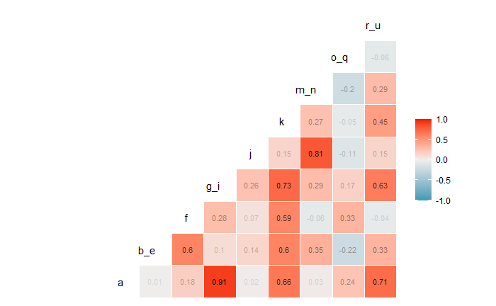

```r
GGally::ggcorr(prod_industry_data_scale,
    label = TRUE,
    label_size = 3,
    label_round = 2,
    label_alpha = TRUE,
    hjust = 1,
    layout.exp = 0.5
  )
```

Call libraries

```r
library(cluster)
library(factoextra)
library(dendextend)
library(corrplot)
```

Take productivity A

```r
diss_matrix_a <- prod_industry_data_scale %>%
              select(a) %>%
              dist(method = "euclidean")
```

Create a dissimilarity matrix showing distances

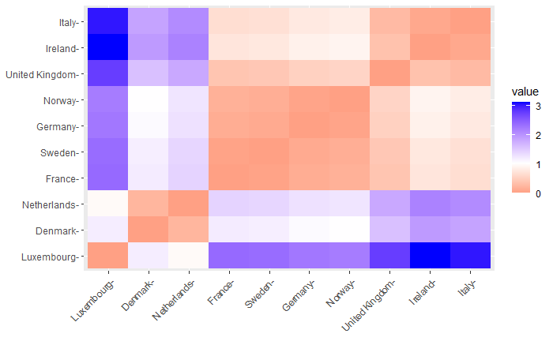

```r
fviz_dist(diss_matrix_a)
```

Build dendrogram

```r
clusters_a <- diss_matrix_a %>%
                 hclust(method = "complete")
```

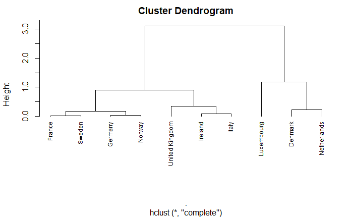

```r
clusters_a %>%
  plot(cex = 0.75, hang = -5)
```

Take productivity B-E

```r
diss_matrix_b_e <- prod_industry_data_scale %>%
              select(b_e) %>%
              dist(method = "euclidean")
```

Create a dissimilarity matrix showing distances

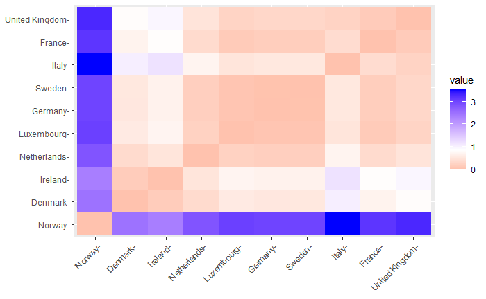

```r
fviz_dist(diss_matrix_b_e)
```

Build dendrogram

```r
clusters_b_e <- diss_matrix_b_e %>%
                 hclust(method = "complete")
```